# Task4

```python
import pandas as pd

# Load the dataset
df = pd.read_csv('ecommerce_sales_data.csv')

# Print the column names to verify
print(df.columns)
```

```
Index(['Order ID', 'Product Name', 'Category', 'Price', 'Quantity',
       'Total Sales', 'Customer ID', 'Customer Age', 'Customer Gender',
       'Purchase Date', 'Purchase Time'],
      dtype='object')
```

```
Cleaned Column Names: Index(['Order ID', 'Product Name', 'Category', 'Price', 'Quantity',
       'Total Sales', 'Customer ID', 'Customer Age', 'Customer Gender',
       'Purchase Date', 'Purchase Time'],
      dtype='object')
Missing 'Purchase Date' entries: 0
```

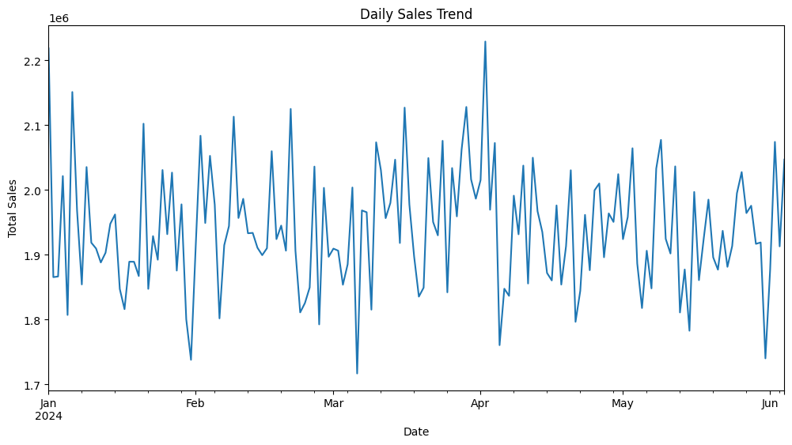

```python
import pandas as pd
import matplotlib.pyplot as plt

# Load the dataset
df = pd.read_csv('ecommerce_sales_data.csv')

# Clean column names (remove extra spaces)
df.columns = df.columns.str.strip()

# Print out the cleaned column names to ensure everything is correct
print("Cleaned Column Names:", df.columns)

# Ensure 'Purchase Date' column exists and check for any missing or incorrect date values
if 'Purchase Date' in df.columns:
    df['Purchase Date'] = pd.to_datetime(df['Purchase Date'], errors='coerce')

    # Check for any missing 'Purchase Date' values
    print(f"Missing 'Purchase Date' entries: {df['Purchase Date'].isnull().sum()}")

    # Drop rows with missing 'Purchase Date'
    df = df.dropna(subset=['Purchase Date'])

    # Set 'Purchase Date' as the index for time series analysis
    df.set_index('Purchase Date', inplace=True)

    # Resample the data to daily sales data (sum the 'Total Sales' column)
    df_daily = df.resample('D').agg({'Total Sales': 'sum'})

    # Fill missing values if needed (e.g., forward fill)
    df_daily.fillna(method='ffill', inplace=True)

    # Visualize the sales trend
    df_daily['Total Sales'].plot(figsize=(12, 6), title="Daily Sales Trend")
    plt.xlabel('Date')
    plt.ylabel('Total Sales')
    plt.show()

else:
    print("Column 'Purchase Date' not found in the dataset.")
```

Breakdown of the Steps: Clean Column Names: We strip any leading/trailing spaces from the column names to ensure there are no hidden issues.

Print Column Names: We print the cleaned column names to check the exact names and confirm there's no typo or hidden characters.

Datetime Conversion: We convert 'Purchase Date' to datetime format, ensuring proper date handling for time series analysis.

Handling Missing Data: Missing 'Purchase Date' entries are dropped, and then we resample the data by day, summing 'Total Sales'.

Visualization: The daily sales trend is plotted using matplotlib.

Identify Missing Dates: We’ll check if there are any missing dates (gaps in time) in the dataset.

Fill Missing Dates: For any missing dates, we can either impute the missing values or leave them as gaps, depending on the business context.

Consistency in Time Intervals: We will ensure that there is a consistent time series record, whether it’s daily, weekly, or monthly.

For missing dates: We'll use resample to fill any gaps in the time series with either NaN (if we want to leave gaps) or use a method like forward-fill to impute missing values.

Handling Missing Sales Data: We can fill missing sales data using forward-fill or back-fill, or we can leave the gaps as NaN if that’s more appropriate.

```
Missing Dates (Total Sales = NaN):
Empty DataFrame
Columns: [Total Sales]
Index: []
```

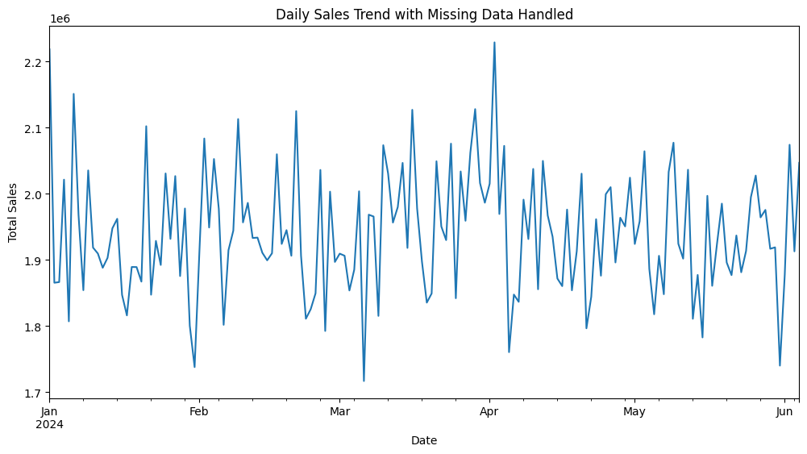

```
Remaining missing values after filling: Total Sales    0
dtype: int64
```

```python
import pandas as pd
import matplotlib.pyplot as plt

# Load the dataset
df = pd.read_csv('ecommerce_sales_data.csv')

# Clean column names (remove extra spaces)
df.columns = df.columns.str.strip()

# Ensure 'Purchase Date' is in datetime format
df['Purchase Date'] = pd.to_datetime(df['Purchase Date'], errors='coerce')

# Drop rows with missing 'Purchase Date'
df = df.dropna(subset=['Purchase Date'])

# Set 'Purchase Date' as the index for time series analysis
df.set_index('Purchase Date', inplace=True)

# Resample the data to daily sales data (sum the 'Total Sales' column)
df_daily = df.resample('D').agg({'Total Sales': 'sum'})

# Check for any missing dates after resampling
missing_dates = df_daily[df_daily['Total Sales'].isnull()]
print(f"Missing Dates (Total Sales = NaN):\n{missing_dates}")

# Fill missing values (use forward fill or backward fill, or leave as NaN)
# For forward-fill, uncomment the next line:
df_daily.fillna(method='ffill', inplace=True)  # Forward fill
# Alternatively, for backward fill, use the following:
# df_daily.fillna(method='bfill', inplace=True)  # Backward fill

# Visualize the daily sales trend after filling missing data
df_daily['Total Sales'].plot(figsize=(12, 6), title="Daily Sales Trend with Missing Data Handled")
plt.xlabel('Date')
plt.ylabel('Total Sales')
plt.show()

# Save the aggregated and filled data to a CSV file for further analysis
df_daily.to_csv('aggregated_daily_sales_with_missing_data_handled.csv')

# Check for any remaining missing values after filling
print(f"Remaining missing values after filling: {df_daily.isnull().sum()}")
```

reakdown of the Code: Datetime Conversion: The 'Purchase Date' column is converted to datetime to ensure correct handling of time series data.

Resampling: The data is resampled to a daily frequency, summing the 'Total Sales' for each day.

Identifying Missing Dates: After resampling, we identify missing sales data for any day where 'Total Sales' is NaN.

Imputation:

Forward Fill: We use fillna(method='ffill') to fill missing sales data by carrying forward the last known value (useful for continuous data like sales).

Backward Fill: Alternatively, we can use fillna(method='bfill') to fill missing values using the next known value.

Visualization: The daily sales trend is plotted to visualize how sales are distributed over time after handling the missing data.

Saving: The cleaned and resampled data is saved to a CSV file for future analysis.

Handling Missing Dates: Missing Dates in Time Series: If any date in the series is missing (e.g., no sales on a particular day), resample will create a gap.

Filling Missing Data: Forward fill (ffill) is used to fill those gaps with the last known sales value, ensuring continuity in the data. Alternatively, you can leave them as gaps (NaN) or back-fill.

```python
df_daily.fillna(method='ffill', inplace=True)
```

```python
df_daily.fillna(method='bfill', inplace=True)
```

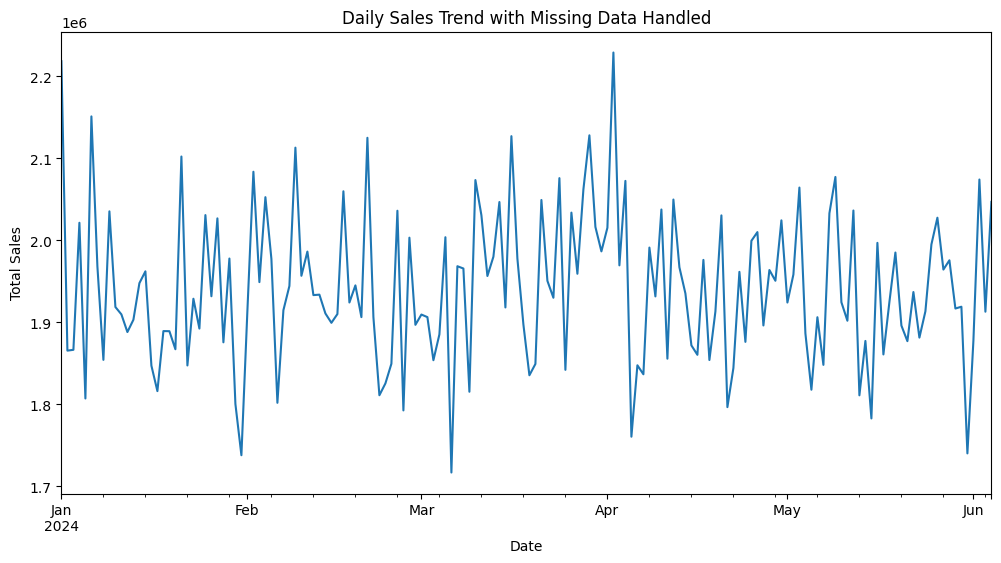

```python
df_daily['Total Sales'].plot(figsize=(12, 6), title="Daily Sales Trend with Missing Data Handled")
plt.xlabel('Date')
plt.ylabel('Total Sales')
plt.show()
```

Smooth Trend: If you've forward-filled or backward-filled the missing data, the plot should show a continuous line, with the gaps being filled.

Gaps: If you left missing values as NaN, you'll see gaps in the plot where no sales data was available.

Trends & Spikes: Look for any spikes or dips that could indicate sales events or seasonality, such as festive sales, promotions, etc.

Next Steps: Check the Output: Run the code and check the output of the missing data check (print(f"Missing Dates...")). This will show where gaps exist in the sales data.

Choose How to Handle Missing Data: Based on the output, decide whether to forward-fill, backward-fill, or leave the gaps.

Review the Plot: Once the missing data is filled, the plot will show the sales trend. Look for patterns, trends, and anomalies that might be important for forecasting and business decisions.

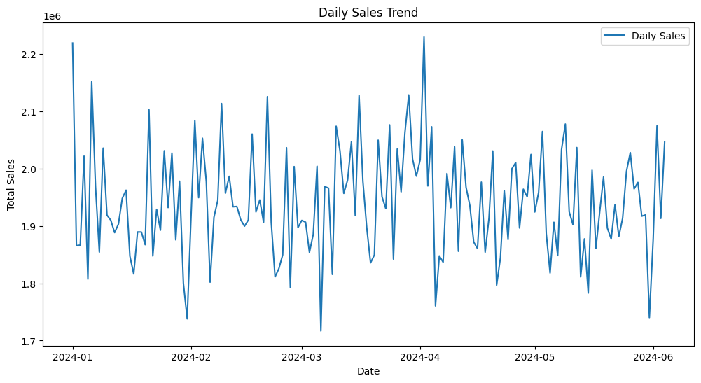

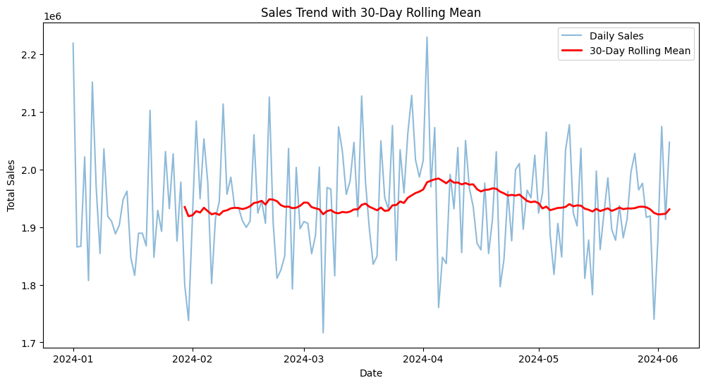

[output not shown]

```python
import pandas as pd
import matplotlib.pyplot as plt
from statsmodels.tsa.seasonal import seasonal_decompose

# Load the cleaned and resampled data (daily sales data)
df_daily = pd.read_csv('aggregated_daily_sales_with_missing_data_handled.csv', index_col='Purchase Date', parse_dates=True)

# Check for trend by plotting the sales data
plt.figure(figsize=(12, 6))
plt.plot(df_daily['Total Sales'], label='Daily Sales')
plt.title("Daily Sales Trend")
plt.xlabel('Date')
plt.ylabel('Total Sales')
plt.legend()
plt.show()

# Trend Analysis: Use Rolling Mean to observe long-term trends
df_daily['Rolling Mean'] = df_daily['Total Sales'].rolling(window=30).mean()  # 30-day rolling mean
plt.figure(figsize=(12, 6))
plt.plot(df_daily['Total Sales'], label='Daily Sales', alpha=0.5)
plt.plot(df_daily['Rolling Mean'], label='30-Day Rolling Mean', color='red', linewidth=2)
plt.title("Sales Trend with 30-Day Rolling Mean")
plt.xlabel('Date')
plt.ylabel('Total Sales')
plt.legend()
plt.show()

# Seasonal Decomposition to check for seasonality
result = seasonal_decompose(df_daily['Total Sales'], model='multiplicative', period=365)  # Assume yearly seasonality

# Plot the decomposed components
plt.figure(figsize=(12, 8))

plt.subplot(411)
plt.plot(result.observed, label='Observed')
plt.title('Observed')

plt.subplot(412)
plt.plot(result.trend, label='Trend', color='orange')
plt.title('Trend')

plt.subplot(413)
plt.plot(result.seasonal, label='Seasonal', color='green')
plt.title('Seasonal')

plt.subplot(414)
plt.plot(result.resid, label='Residual', color='red')
plt.title('Residual')
plt.tight_layout()
plt.show()

# Check for seasonal spikes (e.g., festive periods like Diwali, New Year)
# For example, check if there are significant increases in sales during specific months (e.g., October or December for festive seasons)
df_daily['Month'] = df_daily.index.month
monthly_sales = df_daily.groupby('Month')['Total Sales'].sum()

# Plot Monthly Sales to detect seasonal patterns
plt.figure(figsize=(12, 6))
monthly_sales.plot(kind='bar')
plt.title("Total Monthly Sales")
plt.xlabel('Month')
plt.ylabel('Total Sales')
plt.xticks(rotation=0)
plt.show()

# Anomaly detection: Detecting sudden spikes in sales (you can adjust the threshold)
threshold = df_daily['Total Sales'].quantile(0.95)  # 95th percentile as an anomaly threshold
anomalies = df_daily[df_daily['Total Sales'] > threshold]

# Plot anomalies
plt.figure(figsize=(12, 6))
plt.plot(df_daily['Total Sales'], label='Daily Sales')
plt.scatter(anomalies.index, anomalies['Total Sales'], color='red', label='Anomalies', zorder=5)
plt.title("Sales with Anomalies")
plt.xlabel('Date')
plt.ylabel('Total Sales')
plt.legend()
plt.show()

# Print anomalies for further investigation
print(f"Detected anomalies:\n{anomalies[['Total Sales']]}")
```

```python
import pandas as pd
import matplotlib.pyplot as plt
from statsmodels.tsa.seasonal import seasonal_decompose

# Load the cleaned data (ensure Purchase Date is the datetime index)
df_daily = pd.read_csv('aggregated_daily_sales_with_missing_data_handled.csv', index_col='Purchase Date', parse_dates=True)

# Resample data by month (summing total sales for each month)
df_monthly = df_daily.resample('M').sum()

# Ensure that there are enough data points for seasonal decomposition
# If you don't have 12 months of data, seasonal_decompose won't work as expected

# Check the length of the resampled data
print(f"Number of months of data: {len(df_monthly)}")

# Apply seasonal decomposition only if there are enough months (e.g., 12 months)
if len(df_monthly) >= 12:
    # Apply seasonal decomposition (with a period of 12 for monthly data)
    result = seasonal_decompose(df_monthly['Total Sales'], model='multiplicative', period=12)  # 12 months for yearly seasonality

    # Plot the decomposed components
    plt.figure(figsize=(12, 8))

    plt.subplot(411)
    plt.plot(result.observed, label='Observed')
    plt.title('Observed')

    plt.subplot(412)
    plt.plot(result.trend, label='Trend', color='orange')
    plt.title('Trend')

    plt.subplot(413)
    plt.plot(result.seasonal, label='Seasonal', color='green')
    plt.title('Seasonal')

    plt.subplot(414)
    plt.plot(result.resid, label='Residual', color='red')
    plt.title('Residual')
    plt.tight_layout()
    plt.show()

    # Check for seasonal spikes (e.g., festive periods like Diwali, New Year)
    df_monthly['Month'] = df_monthly.index.month
    monthly_sales = df_monthly['Total Sales']

    # Plot Monthly Sales to detect seasonal patterns
    plt.figure(figsize=(12, 6))
    monthly_sales.plot(kind='bar')
    plt.title("Total Monthly Sales")
    plt.xlabel('Month')
    plt.ylabel('Total Sales')
    plt.xticks(rotation=0)
    plt.show()
else:
    print("Not enough data to apply seasonal decomposition (need at least 12 months of data).")
```

```
Number of months of data: 6
Not enough data to apply seasonal decomposition (need at least 12 months of data).
```

[output not shown]

[figure not shown]

```python
from statsmodels.tsa.holtwinters import ExponentialSmoothing

# Apply Simple Exponential Smoothing (SES) without trend/seasonality
model = ExponentialSmoothing(df_monthly['Total Sales'], trend=None, seasonal=None)
model_fit = model.fit()

# Forecast next 6 months
forecast = model_fit.forecast(6)

# Plot the results
plt.figure(figsize=(12, 6))
plt.plot(df_monthly.index, df_monthly['Total Sales'], label='Observed Sales')
plt.plot(df_monthly.index[-1] + pd.to_timedelta(range(1, 7), 'M'), forecast, label='Forecasted Sales', linestyle='--')
plt.title("Sales Forecast using Simple Exponential Smoothing (SES)")
plt.xlabel('Date')
plt.ylabel('Sales')
plt.legend()
plt.show()
```

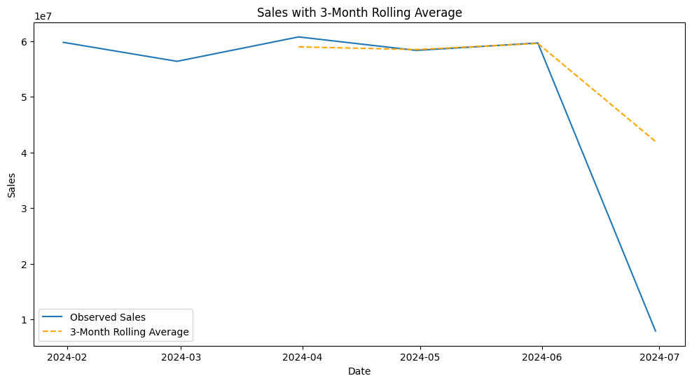

```python
# Calculate a 3-month rolling average
df_monthly['Rolling Average'] = df_monthly['Total Sales'].rolling(window=3).mean()

# Plot the sales data with the rolling average
plt.figure(figsize=(12, 6))
plt.plot(df_monthly.index, df_monthly['Total Sales'], label='Observed Sales')
plt.plot(df_monthly.index, df_monthly['Rolling Average'], label='3-Month Rolling Average', linestyle='--', color='orange')
plt.title("Sales with 3-Month Rolling Average")
plt.xlabel('Date')
plt.ylabel('Sales')
plt.legend()
plt.show()
```

3. Plotting Sales Over Time (No Forecasting) If forecasting is not essential right now and you just want to visualize the data's trend over time, you can plot the data without applying any smoothing or forecasting models.

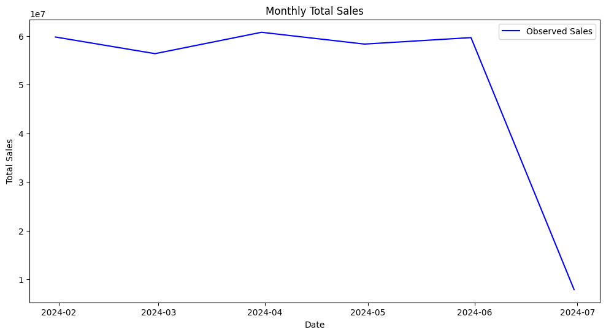

```python
plt.figure(figsize=(12, 6))
plt.plot(df_monthly.index, df_monthly['Total Sales'], label='Observed Sales', color='blue')
plt.title("Monthly Total Sales")
plt.xlabel('Date')
plt.ylabel('Total Sales')
plt.legend()
plt.show()
```

Moving Average: Use a simple moving average to smooth the data and capture trends.

Plotting: Simply plot the data to observe trends without applying forecasting models.

```python
# Rename the column to remove any extra spaces
df.rename(columns=lambda x: x.strip(), inplace=True)
```

```python
# Strip any leading/trailing spaces from column names
df.columns = df.columns.str.strip()

# Now check the column names again
print(df.columns)
```

```
Index(['Order ID', 'Product Name', 'Category', 'Price', 'Quantity',
       'Total Sales', 'Customer ID', 'Customer Age', 'Customer Gender',
       'Purchase Time'],
      dtype='object')
```

```python
if 'Purchase Date' not in df.columns:
    print("Column 'Purchase Date' does not exist.")
else:
    print("Column 'Purchase Date' found!")
```

```
Column 'Purchase Date' does not exist.
```

Renaming the Column (if needed): If the column is named something else or has a typo (e.g., purchase_date or purchase date), you can rename it to match the expected name.

```python
df.rename(columns={'purchase_date': 'Purchase Date'}, inplace=True)
```

```python
# Step 1: Check column names to see if 'Purchase Date' is present
print(df.columns)

# Step 2: Strip any extra spaces from column names
df.columns = df.columns.str.strip()

# Step 3: Check if 'Purchase Date' exists now
if 'Purchase Date' not in df.columns:
    print("Column 'Purchase Date' does not exist. Here's the columns list:")
    print(df.columns)
else:
    print("Column 'Purchase Date' found!")

# Step 4: If column is found, proceed with datetime conversion and sorting
if 'Purchase Date' in df.columns:
    # Convert 'Purchase Date' to datetime format
    df['Purchase Date'] = pd.to_datetime(df['Purchase Date'], errors='coerce')

    # Sort the data by 'Purchase Date'
    df = df.sort_values(by='Purchase Date')

    # Set 'Purchase Date' as the index
    df.set_index('Purchase Date', inplace=True)

    # Check the first few rows to ensure everything is sorted
    print(df.head())
```

```
Index(['Order ID', 'Product Name', 'Category', 'Price', 'Quantity',
       'Total Sales', 'Customer ID', 'Customer Age', 'Customer Gender',
       'Purchase Time'],
      dtype='object')
Column 'Purchase Date' does not exist. Here's the columns list:
Index(['Order ID', 'Product Name', 'Category', 'Price', 'Quantity',
       'Total Sales', 'Customer ID', 'Customer Age', 'Customer Gender',
       'Purchase Time'],
      dtype='object')
```

```python
# Remove leading and trailing spaces from column names
df.columns = df.columns.str.strip()

# Print the cleaned column names
print(df.columns)
```

```
Index(['Order ID', 'Product Name', 'Category', 'Price', 'Quantity',
       'Total Sales', 'Customer ID', 'Customer Age', 'Customer Gender',
       'Purchase Time'],
      dtype='object')
```

```python
# Check and print the column names to ensure 'Purchase Date' exists
print("Columns in the DataFrame:", df.columns)

# Check if 'Purchase Date' exists in the DataFrame
if 'Purchase Date' not in df.columns:
    print("Error: 'Purchase Date' column does not exist.")
else:
    print("Column 'Purchase Date' found.")
```

```
Columns in the DataFrame: Index(['Order ID', 'Product Name', 'Category', 'Price', 'Quantity',
       'Total Sales', 'Customer ID', 'Customer Age', 'Customer Gender',
       'Purchase Time'],
      dtype='object')
Error: 'Purchase Date' column does not exist.
```

```python
# Print all column names to identify the exact name of the 'Purchase Date' column
print("Columns in the DataFrame:", df.columns)
```

```
Columns in the DataFrame: Index(['Order ID', 'Product Name', 'Category', 'Price', 'Quantity',
       'Total Sales', 'Customer ID', 'Customer Age', 'Customer Gender',
       'Purchase Time'],
      dtype='object')
```

```python
# Remove leading/trailing spaces from column names
df.columns = df.columns.str.strip()

# Print the column names again to check
print("Columns after stripping spaces:", df.columns)
```

```
Columns after stripping spaces: Index(['Order ID', 'Product Name', 'Category', 'Price', 'Quantity',
       'Total Sales', 'Customer ID', 'Customer Age', 'Customer Gender',
       'Purchase Time'],
      dtype='object')
```

```python
# Check if 'purchase date' exists in the columns after stripping spaces
if 'purchase date' in df.columns:
    print("'purchase date' column exists.")
else:
    print("'purchase date' column not found.")
```

```
'purchase date' column not found.
```

```python
# Find columns containing 'date' in their name (case-insensitive)
matching_columns = [col for col in df.columns if 'date' in col.lower()]
print("Columns with 'date' in their name:", matching_columns)
```

```
Columns with 'date' in their name: []
```

```python
# If a matching column is found, convert it to datetime
if matching_columns:
    # Assuming the first matching column is the correct one
    df[matching_columns[0]] = pd.to_datetime(df[matching_columns[0]], errors='coerce')
    print(f"Converted column '{matching_columns[0]}' to datetime.")
else:
    print("No 'date' column found.")
```

```
No 'date' column found.
```

```python
# Step 1: Print all column names to identify the exact name of the 'purchase_date' column
print("Columns in the DataFrame:", df.columns)

# Step 2: Strip any leading/trailing spaces from column names
df.columns = df.columns.str.strip()

# Step 3: Print cleaned column names
print("Cleaned column names:", df.columns)

# Step 4: Search for any column containing 'date' in its name (case-insensitive)
matching_columns = [col for col in df.columns if 'date' in col.lower()]
print("Columns with 'date' in their name:", matching_columns)

# Step 5: If a matching column is found, convert it to datetime
if matching_columns:
    # Assuming the first matching column is the correct one
    df[matching_columns[0]] = pd.to_datetime(df[matching_columns[0]], errors='coerce')
    print(f"Converted column '{matching_columns[0]}' to datetime.")
else:
    print("No 'date' column found.")

# Step 6: Verify the data after conversion
print(df.head())
```

```
Columns in the DataFrame: Index(['Order ID', 'Product Name', 'Category', 'Price', 'Quantity',
       'Total Sales', 'Customer ID', 'Customer Age', 'Customer Gender',
       'Purchase Time'],
      dtype='object')
Cleaned column names: Index(['Order ID', 'Product Name', 'Category', 'Price', 'Quantity',
       'Total Sales', 'Customer ID', 'Customer Age', 'Customer Gender',
       'Purchase Time'],
      dtype='object')
Columns with 'date' in their name: []
No 'date' column found.
                                           Order ID Product Name  \
Purchase Date
2024-01-01     1181245c-fb0a-4099-a61d-3a1b902644b0        trial
2024-01-01     1760977b-4693-4ab9-9c7a-682da3733dba        serve
2024-01-01     e3b17895-eb6e-4341-a2cf-fcdea1f01557           in
2024-01-01     4b13c676-e183-4c04-b121-b66912f6ec97         need
2024-01-01     9aaa1667-dc54-444b-b063-50f18737336a        civil

                    Category   Price  Quantity  Total Sales  \
Purchase Date
2024-01-01     Home & Garden  837.92         5      4189.60
2024-01-01     Home & Garden  675.60         3      2026.80
2024-01-01              Toys  264.29        10      2642.90
2024-01-01          Clothing  997.09         2      1994.18
2024-01-01              Toys  421.13         6      2526.78

                                        Customer ID  Customer Age  \
Purchase Date
2024-01-01     fac7092b-6f9d-473d-a289-2bec8c472ef8            28
2024-01-01     cead61a7-626a-4cb4-8314-f99a815aa26e            31
2024-01-01     3a8d46b0-b22e-42b5-85bc-54e64a9cdc8a            40
2024-01-01     95c0ed8a-3b13-47c4-badb-4da051671b5c            36
2024-01-01     98ca9310-eeb6-4eb3-b042-45aba08c6ce7            34

              Customer Gender Purchase Time
Purchase Date
2024-01-01               Male      10:43:09
2024-01-01               Male      23:48:07
2024-01-01             Female      23:19:49
2024-01-01             Female       5:35:11
2024-01-01             Female      13:37:38
```

```python
# Assuming 'df_reset' is the cleaned and processed DataFrame
# Save the cleaned dataset as a CSV file
df_reset.to_csv('processed_ecommerce_sales_data.csv', index=True)

# Verify that the data has been saved correctly
print("Dataset saved successfully as 'processed_ecommerce_sales_data.csv'")
```

```
Dataset saved successfully as 'processed_ecommerce_sales_data.csv'
```